# I. Модель, прогнозирующая кредитный дефолт (случайный лес)

```python
import pandas as pd
import numpy as np

data = pd.read_csv('germancredit.csv')
```

Загружаем данные.

```python
data.isnull().any()
```

```
Default            False
checkingstatus1    False
duration           False
history            False
purpose            False
amount             False
savings            False
employ             False
installment        False
status             False
others             False
residence          False
property           False
age                False
otherplans         False
housing            False
cards              False
job                False
liable             False
tele               False
foreign            False
dtype: bool
```

Пропущенных значений нет.

```python
data.head()
```

|  | Default | checkingstatus1 | duration | history | purpose | amount | savings | employ | installment | status | ... | residence | property | age | otherplans | housing | cards | job | liable | tele | foreign |
| --- | --- | --- | --- | --- | --- | --- | --- | --- | --- | --- | --- | --- | --- | --- | --- | --- | --- | --- | --- | --- | --- |
| 0 | 0 | A11 | 6 | A34 | A43 | 1169 | A65 | A75 | 4 | A93 | ... | 4 | A121 | 67 | A143 | A152 | 2 | A173 | 1 | A192 | A201 |
| 1 | 1 | A12 | 48 | A32 | A43 | 5951 | A61 | A73 | 2 | A92 | ... | 2 | A121 | 22 | A143 | A152 | 1 | A173 | 1 | A191 | A201 |
| 2 | 0 | A14 | 12 | A34 | A46 | 2096 | A61 | A74 | 2 | A93 | ... | 3 | A121 | 49 | A143 | A152 | 1 | A172 | 2 | A191 | A201 |
| 3 | 0 | A11 | 42 | A32 | A42 | 7882 | A61 | A74 | 2 | A93 | ... | 4 | A122 | 45 | A143 | A153 | 1 | A173 | 2 | A191 | A201 |
| 4 | 1 | A11 | 24 | A33 | A40 | 4870 | A61 | A73 | 3 | A93 | ... | 4 | A124 | 53 | A143 | A153 | 2 | A173 | 2 | A191 | A201 |

5 rows × 21 columns

```python
data.info()
```

```
<class 'pandas.core.frame.DataFrame'>
RangeIndex: 1000 entries, 0 to 999
Data columns (total 21 columns):
Default            1000 non-null int64
checkingstatus1    1000 non-null object
duration           1000 non-null int64
history            1000 non-null object
purpose            1000 non-null object
amount             1000 non-null int64
savings            1000 non-null object
employ             1000 non-null object
installment        1000 non-null int64
status             1000 non-null object
others             1000 non-null object
residence          1000 non-null int64
property           1000 non-null object
age                1000 non-null int64
otherplans         1000 non-null object
housing            1000 non-null object
cards              1000 non-null int64
job                1000 non-null object
liable             1000 non-null int64
tele               1000 non-null object
foreign            1000 non-null object
dtypes: int64(8), object(13)
memory usage: 164.1+ KB
```

Выделяем категориальные и числовые переменные.

```python
num_cols = []
cat_cols = []

for column in data.columns[1:]:
    if data[column].dtype == 'int64':
        num_cols.append(column)
    else:
        cat_cols.append(column)
```

```python
cat_cols
```

```
['checkingstatus1',
 'history',
 'purpose',
 'savings',
 'employ',
 'status',
 'others',
 'property',
 'otherplans',
 'housing',
 'job',
 'tele',
 'foreign']
```

```python
num_cols
```

```
['duration', 'amount', 'installment', 'residence', 'age', 'cards', 'liable']
```

Кодируем категориальные переменные с помощью DictVectorizer.

```python
cat_dict = data[cat_cols].T.to_dict().values()
```

```python
from sklearn.feature_extraction import DictVectorizer as DV

vectorizer = DV(sparse = False)
vec_cat = vectorizer.fit_transform(cat_dict)
```

Выделяем целевую переменную и предикторы.

```python
X = np.hstack((data[num_cols], vec_cat))
```

```python
y = data['Default']
```

Обучаем случайный лес, подбираем число деревьев по сетке с кросс-валидацией на 4 фолда. Случайный лес - очень эффективный алгоритм классификации, простой в использовании, т.к. не требует настройки большого числа параметров, представляет собой ансамбль решающих деревьев, устойчив к переобучению, нечувствителен к масштабированию, одинаково хорошо обрабатывает дискретные и непрерывные признаки.

```python
from sklearn.ensemble import RandomForestClassifier
classifier = RandomForestClassifier()

from sklearn import cross_validation, grid_search, linear_model, metrics
parameters_grid = {'n_estimators' : [100, 150, 200, 300, 500, 700, 1000]}
```

```python
grid_cv = grid_search.GridSearchCV(classifier, parameters_grid, scoring = 'roc_auc', cv = 4)
grid_cv.fit(X, y)
```

```
GridSearchCV(cv=4, error_score='raise',
       estimator=RandomForestClassifier(bootstrap=True, class_weight=None, criterion='gini',
            max_depth=None, max_features='auto', max_leaf_nodes=None,
            min_samples_leaf=1, min_samples_split=2,
            min_weight_fraction_leaf=0.0, n_estimators=10, n_jobs=1,
            oob_score=False, random_state=None, verbose=0,
            warm_start=False),
       fit_params={}, iid=True, n_jobs=1,
       param_grid={'n_estimators': [100, 150, 200, 300, 500, 700, 1000]},
       pre_dispatch='2*n_jobs', refit=True, scoring='roc_auc', verbose=0)
```

```python
print grid_cv.best_score_
print grid_cv.best_params_
```

```
0.802142857143
{'n_estimators': 300}
```

Итак, мы получили качество 0.8 по ROC-AUC (площадь под ROC кривой) при 300 деревьях.

Разобьем выборку на тренировочную и тестовую, обучим случайный лес на тренировочной выборке и проверим на тестовой.

```python
from sklearn.cross_validation import train_test_split
X_train, X_test, y_train, y_test = train_test_split(X, y, test_size=0.25)
```

```python
classifier = RandomForestClassifier(n_estimators = 300)
classifier.fit(X_train, y_train)
pred = classifier.predict(X_test)
print metrics.accuracy_score(y_test, pred)
```

```
0.788
```

Получаем долю правильных ответов 78,8% на тестовой выборке.

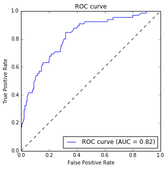

```python
from sklearn.metrics import roc_curve, roc_auc_score

pred_scr = classifier.predict_proba(X_test)[:, 1]
roc_auc = roc_auc_score(y_test, pred_scr)
fpr, tpr, thresholds = roc_curve(y_test, pred_scr)

plt.figure(figsize=(5, 5))
plt.plot(fpr, tpr, label='ROC curve (AUC = %0.2f)' % (roc_auc))
plt.plot([0, 1], [0, 1], '--', color=(0, 0, 0))
plt.xlim([0, 1])
plt.ylim([0, 1])
plt.xlabel('False Positive Rate')
plt.ylabel('True Positive Rate')
plt.legend(loc="lower right")
plt.title('ROC curve')
```

ROC кривая показывает, как будут меняться доли правильно и ложно определенных клиентов, которым не стоит выдавать кредит, при варьировании порога классификатора. Площадь под ROC кривой составила 0.82, это достаточно хороший результат. Чем она больше, тем лучше.